# Statistics : Homework No. 07

Levon Khachatryan

Due time/date: 21:20, 4 December, 2018

R version is following:

```r
R.version.string
```

```
## [1] "R version 3.5.1 (2018-07-02)"
```

I converted xlsx to csv, due to the import of the xlsx file I had some problems with read.xlsx package, but i think it doesn’t matter.

## Problem 4.

At first let’s import necessary file:

```r
rm(list = ls())
setwd("D:/MyProjects/StatisticHomeworks/Homework7")
dat <- read.csv("Hw07p04.csv", stringsAsFactors = FALSE,header = FALSE)
head(dat)
```

```
##   V1 V2 V3 V4 V5 V6 V7 V8 V9 V10 V11
## 1  1  0  1  1  1  1  0  1  0   0   1
## 2  2  0  0  0  0  0  0  0  0   1   0
## 3  3  1  1  0  1  1  0  0  1   1   0
## 4  4  0  1  0  0  0  0  0  0   1   1
## 5  5  1  1  0  1  1  1  1  0   0   0
## 6  6  0  1  1  1  1  0  1  1   1   1
```

**$\hat{p}$** has the following form:  
$\hat{p} = \frac{X_{1}+X_{2}+...+X_{10}}{10}$  
For future calculations, I will add a new column **p** to our data set, where the appropriate value for $\hat{p}$ will be stored.

```r
dat["p"] <- rowSums( dat[,2:11] )/10
head(dat)
```

```
##   V1 V2 V3 V4 V5 V6 V7 V8 V9 V10 V11   p
## 1  1  0  1  1  1  1  0  1  0   0   1 0.6
## 2  2  0  0  0  0  0  0  0  0   1   0 0.1
## 3  3  1  1  0  1  1  0  0  1   1   0 0.6
## 4  4  0  1  0  0  0  0  0  0   1   1 0.3
## 5  5  1  1  0  1  1  1  1  0   0   0 0.6
## 6  6  0  1  1  1  1  0  1  1   1   1 0.8
```

1. Construct the distribution (histogram and KDE) of $\hat{p}$

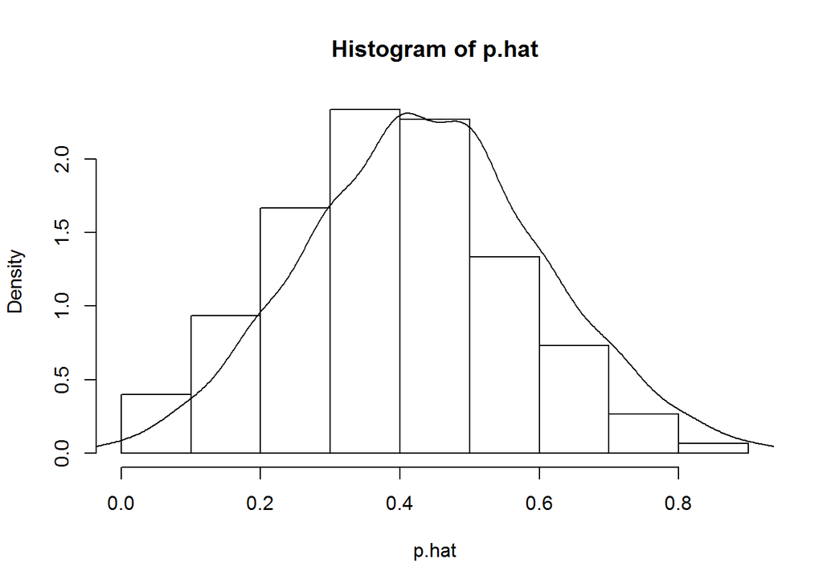

```r
set.seed(1)
p.hat <- dat[,"p"]
hist(p.hat, freq = FALSE)
dens <- density(p.hat)
lines(dens)
```

2. calculate the mean of all estimates $\hat{p}$

```r
mean(p.hat)
```

```
## [1] 0.4373333
```

3. What do you think, was the coin fair ?  
   I think that 150 experiments are not enough to say something about the fairness of the coin , but if I supposed to say something, I will say that it is not a fair coin, because the mean is not equal to 5.

## Problem 5 - d

So my estimator is the following:  
$\hat{\lambda}_{n}=\frac{X_{1}+X_{2}+...+X_{n}}{n+1}$

```r
rm(list = ls())
setwd("D:/MyProjects/StatisticHomeworks/Homework7")
dat1 <- read.csv("Hw07p05.csv", stringsAsFactors = FALSE,header = FALSE)
head(dat1)
```

```
##   V1 V2 V3 V4 V5 V6 V7 V8 V9 V10
## 1  4  1  6  2  5  3  4  4  3   5
## 2  5  7  1  7  3  0  7  1  3   2
## 3  3  3  4  6  6  2  5  3  1   3
## 4  4  1  5  1  1  2  4  3  3   4
## 5  5  5  4  2  5  1  2  0  5   4
## 6  3  4  3  2  3  4  4  4  3   5
```

My task is to construct the histogram and KDE for the estimator $\hat{\lambda}_{10}$.

```r
dat1["l"] <- rowSums(dat1[,1:10])/11
head(dat1)
```

```
##   V1 V2 V3 V4 V5 V6 V7 V8 V9 V10        l
## 1  4  1  6  2  5  3  4  4  3   5 3.363636
## 2  5  7  1  7  3  0  7  1  3   2 3.272727
## 3  3  3  4  6  6  2  5  3  1   3 3.272727
## 4  4  1  5  1  1  2  4  3  3   4 2.545455
## 5  5  5  4  2  5  1  2  0  5   4 3.000000
## 6  3  4  3  2  3  4  4  4  3   5 3.181818
```

I will do the same as in the 4th example.

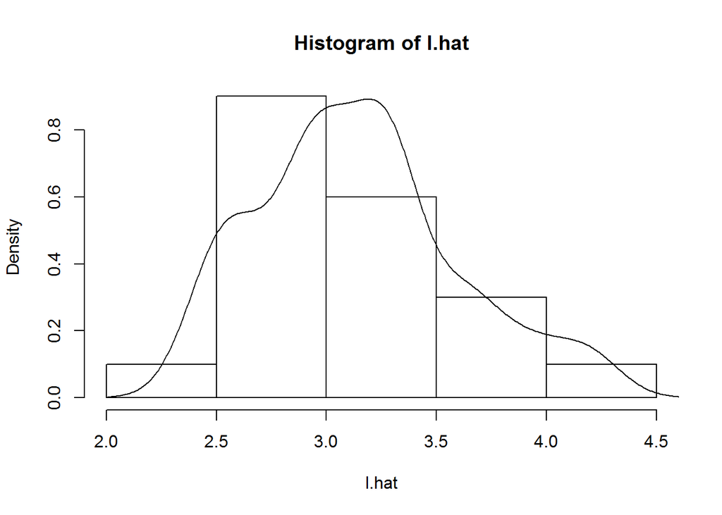

```r
set.seed(1)
l.hat <- dat1[,"l"]
hist(l.hat, freq = FALSE)
dens <- density(l.hat)
lines(dens)
```

## Problem 6 - b

```r
NumberOfTrials <- 200
ListOfMax <- list()
ListOfMin <- list()
for (i in 1:NumberOfTrials){
  SeqFromUnif <- runif(n = 100, min = -1, max = 1)
  ListOfMax[[i]] <- max(SeqFromUnif)
  ListOfMin[[i]] <- min(SeqFromUnif)
  TheoriticalPDF <- dunif(SeqFromUnif)
}
ListOfMax <- as.numeric(ListOfMax)
ListOfMin <- as.numeric(ListOfMin)
```

For $X_{(n)}$ it will be the following:

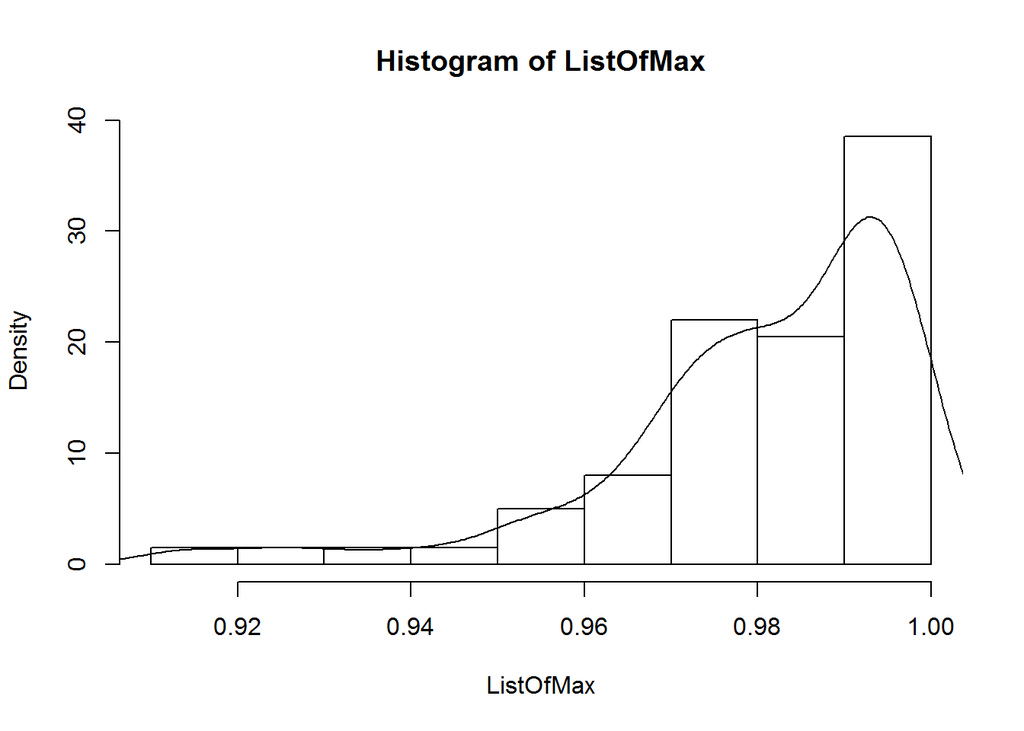

```r
set.seed(1)
hist(ListOfMax, freq = FALSE)
dens <- density(ListOfMax)
lines(dens)
```

And for $X_{(1)}$:

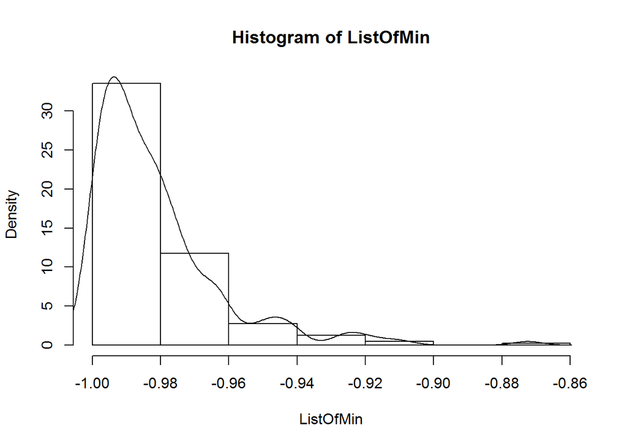

```r
set.seed(1)
hist(ListOfMin, freq = FALSE)
dens <- density(ListOfMin)
lines(dens)
```

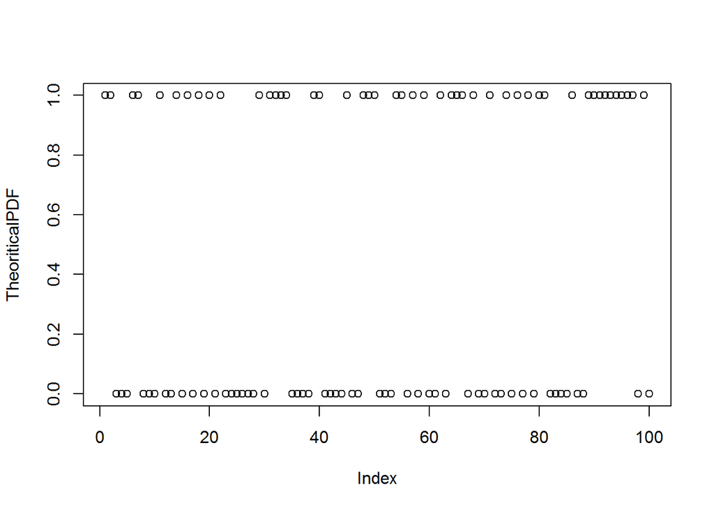

```r
plot(TheoriticalPDF)
```